# Assignment for ASML (Submodule Regression) Epiphany 2021

# Task 3: Assessing cross-validation resampling uncertainty (20 marks)

We know that the output of the cross-validation routine is not deterministic. To shed further light on this, please carry out a simple experiment. Run the cross-validation and estimation routine for the (frequentist) LASSO 50 times, each time identifying the value of $\lambda$ which minimizes the cross-validation criterion, and each time recording which predictor variables have been selected by the Lasso. When finished, produce a table which lists how often each variable has been included.

Build a model which includes all variables which have been selected at least 25 (out of 50) times. Refit this model with the selected variables using ordinary least squares. (Benchmark: The value of $R^2$ of this model should not be worse than about 0.45, and your model should not make use of more than ca 25 genes).

Report the names of the selected genes (in terms of the notation defined in the `Preliminaries`) explicitly.

**Answer:**

```r
# ...
lambda_vals <- c()

row_names <- c()


require(glmnet)
for(i in 1:50){

  gene.lasso.cv= cv.glmnet(X, Time, alpha=1 )

  gene.lasso.min_lambda <- gene.lasso.cv$lambda.min
  lambda_vals[i] <- gene.lasso.min_lambda

  gene.lasso.coef <- coef(gene.lasso.cv, s="lambda.min")
  z <- as.vector(rownames(gene.lasso.coef)[gene.lasso.coef[,1] != 0])
  row_names <- c(row_names,z)
  print(i)

}
```

```
[1] 1
[1] 2
[1] 3
[1] 4
[1] 5
[1] 6
[1] 7
[1] 8
[1] 9
[1] 10
[1] 11
[1] 12
[1] 13
[1] 14
[1] 15
```

[output cut: 35 more lines]

```r
"All selected params"
```

```
[1] "All selected params"
```

```r
result<- as.data.frame(table(row_names))
result
```

| row_names | Freq |
| --- | --- |
| (Intercept) | 50 |
| G1020 | 49 |
| G1021 | 38 |
| G1055 | 4 |
| G1259 | 23 |
| G1456 | 50 |
| G1825 | 50 |
| G2694 | 12 |
| G3395 | 49 |
| G3807 | 49 |

[output cut: 22 more lines]

```r
""
```

```
[1] ""
```

```r
"All Params with counts >= 25"
```

```
[1] "All Params with counts >= 25"
```

```r
data <- result[result[,2] >= 25,]
data
```

|  | row_names | Freq |
| --- | --- | --- |
| 1 | (Intercept) | 50 |
| 2 | G1020 | 49 |
| 3 | G1021 | 38 |
| 6 | G1456 | 50 |
| 7 | G1825 | 50 |
| 9 | G3395 | 49 |
| 10 | G3807 | 49 |
| 12 | G4131 | 50 |
| 13 | G4248 | 49 |
| 15 | G4762 | 49 |

[output cut: 9 more lines]

```r
Selected_var <- as.vector(data[,1])


b <- paste(Selected_var[-1], collapse="+")
b
```

```
[1] "G1020+G1021+G1456+G1825+G3395+G3807+G4131+G4248+G4762+G5352+G5608+G5621+G5950+G6014+G6134+G6321+G6757+G7070"
```

```r
gene.lm.fit <- lm(paste("Time~ ",b,sep = "")    , data = as.data.frame(X))
summary(gene.lm.fit)
```

```
Call:
lm(formula = paste("Time~ ", b, sep = ""), data = as.data.frame(X))

Residuals:
    Min      1Q  Median      3Q     Max
-7.6746 -2.0535 -0.4498  1.8032  8.6811

Coefficients:
            Estimate Std. Error t value Pr(>|t|)
(Intercept)   4.9480     0.2437  20.304  < 2e-16 ***
G1020        -0.3346     0.4058  -0.825 0.410439
G1021        -0.7185     0.4475  -1.606 0.109801
G1456        -0.6735     0.6259  -1.076 0.283069
G1825        -1.9139     0.7080  -2.703 0.007399 **
G3395         0.2724     0.1656   1.645 0.101360
G3807         0.3453     0.3023   1.142 0.254619
G4131         0.2611     0.1193   2.189 0.029608 *
G4248         0.7377     0.2158   3.419 0.000748 ***
G4762         1.1803     0.4735   2.493 0.013408 *
G5352         0.5573     0.4007   1.391 0.165621
G5608        -0.9164     0.5268  -1.740 0.083304 .
G5621        -0.5048     0.2285  -2.209 0.028219 *
G5950        -0.3245     0.5411  -0.600 0.549306
G6014         1.4363     0.5992   2.397 0.017364 *
G6134         0.6487     0.2858   2.270 0.024171 *
G6321        -0.3548     0.1799  -1.973 0.049778 *
G6757         1.2179     0.4241   2.872 0.004478 **
G7070        -1.5462     0.4558  -3.392 0.000821 ***
---
Signif. codes:  0 ‘***’ 0.001 ‘**’ 0.01 ‘*’ 0.05 ‘.’ 0.1 ‘ ’ 1

Residual standard error: 3.353 on 221 degrees of freedom
Multiple R-squared:  0.4612,    Adjusted R-squared:  0.4173
F-statistic: 10.51 on 18 and 221 DF,  p-value: < 2.2e-16
```

```r
"Selected genes:"
```

```
[1] "Selected genes:"
```

```r
Selected_var[-1]
```

```
 [1] "G1020" "G1021" "G1456" "G1825" "G3395" "G3807" "G4131" "G4248" "G4762" "G5352" "G5608" "G5621" "G5950" "G6014"
[15] "G6134" "G6321" "G6757" "G7070"
```

# Task 4: Diagnostics (15 marks)

Carry out some residual diagnostics for the model fitted at the end of Task 3, and display the results graphically.

Attempt a Box-Cox transformation, and refit the model using the suggested transformation. Repeat the residual diagnostics, and also consider the value of $R^2$ of the transformed model. Give your judgement on whether you would prefer the original or the transformed model.

**Answer:**

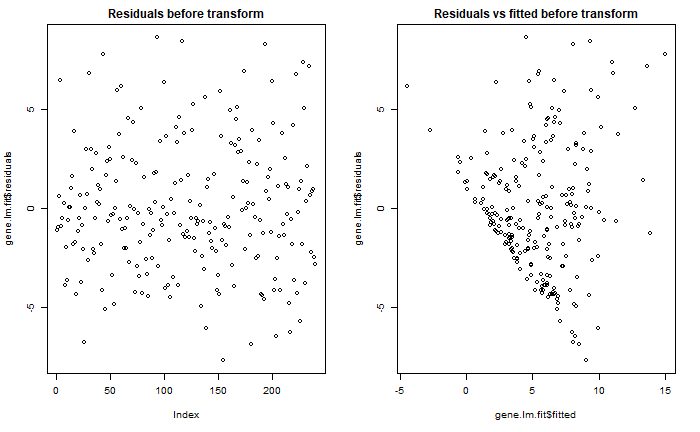

```r
# ...
par(mfrow=c(1,2), cex=0.6)
plot(gene.lm.fit$residuals, main = "Residuals before transform")
plot(gene.lm.fit$fitted, gene.lm.fit$residuals, main = "Residuals vs fitted before transform")
```

```r
require(MASS)
boxcox(gene.lm.fit, main = "BoxCox Plot")
```

```
In lm.fit(x, y, offset = offset, singular.ok = singular.ok, ...) :
 extra argument 㤼㸱main㤼㸲 will be disregarded
```

```r
"Since lambda = 0 we say y^(lambda) = log(y)"
```

```
[1] "Since lambda = 0 we say y^(lambda) = log(y)"
```

```r
Trans_fit <- lm(paste("log(Time) ~ ",b,sep = "")    , data = as.data.frame(X))
summary(Trans_fit)
```

```
Call:
lm(formula = paste("log(Time) ~ ", b, sep = ""), data = as.data.frame(X))

Residuals:
     Min       1Q   Median       3Q      Max
-1.69822 -0.49539  0.02708  0.47648  1.39657

Coefficients:
            Estimate Std. Error t value Pr(>|t|)
(Intercept)  1.29639    0.04670  27.762  < 2e-16 ***
G1020        0.01632    0.07775   0.210 0.833936
G1021       -0.18321    0.08575  -2.137 0.033723 *
G1456       -0.16057    0.11993  -1.339 0.181989
G1825       -0.44511    0.13566  -3.281 0.001202 **
G3395        0.04822    0.03173   1.520 0.129922
G3807        0.13111    0.05793   2.263 0.024587 *
G4131        0.04418    0.02285   1.933 0.054459 .
G4248        0.10502    0.04134   2.540 0.011762 *
G4762        0.22336    0.09073   2.462 0.014589 *
G5352        0.12637    0.07677   1.646 0.101184
G5608       -0.13861    0.10094  -1.373 0.171057
G5621       -0.11378    0.04379  -2.598 0.010003 *
G5950       -0.01228    0.10368  -0.118 0.905849
G6014        0.17367    0.11483   1.512 0.131849
G6134        0.10025    0.05476   1.831 0.068481 .
G6321       -0.07796    0.03447  -2.262 0.024674 *
G6757        0.14512    0.08126   1.786 0.075506 .
G7070       -0.29485    0.08734  -3.376 0.000869 ***
---
Signif. codes:  0 ‘***’ 0.001 ‘**’ 0.01 ‘*’ 0.05 ‘.’ 0.1 ‘ ’ 1

Residual standard error: 0.6425 on 221 degrees of freedom
Multiple R-squared:  0.4447,    Adjusted R-squared:  0.3995
F-statistic: 9.833 on 18 and 221 DF,  p-value: < 2.2e-16
```

[figure not shown]

```r
par(mfrow=c(1,2), cex=0.6)
```

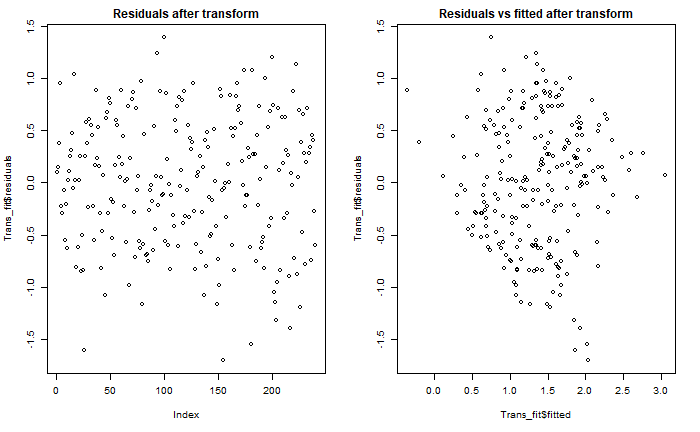

```r
plot(Trans_fit$residuals, main = "Residuals after transform")
plot(Trans_fit$fitted, Trans_fit$residuals, main = "Residuals vs fitted after transform")
```

```r
"Original r squared before transform:"
```

```
[1] "Original r squared before transform:"
```

```r
summary(gene.lm.fit)$r.squared
```

```
[1] 0.4611514
```

```r
""
```

```
[1] ""
```

```r
"New r squared after transform:"
```

```
[1] "New r squared after transform:"
```

```r
summary(Trans_fit)$r.squared
```

```
[1] 0.4447176
```

```r
"Lets start by looking at the resiual analysis:
Residuals plot: before and after the transform the residuals look independent due to no pattern.
Fitted residuals plot: Before the transform clear pattern (trumpet like) which suggests we have violated homoscedasticity
After the transform we see no such shapes. suggesting the boxcox transform has not violated this. From this I am siding with the teansform, but lets compare r squared values.

From the r squared values we can clearly see the non-transformed model has the best statistic

So from this I have had to look else where for a better answer, the model:
As we are using ordinary least squares which assumes normality I will have to say I would prefer to use the transform model as it 'garantees' this wont be violated and we can see it fixes the problem of the data violating homoscedasticity, the only caveat is the transform model has a slighly worse r squared stat."
```

```
[1] "Lets start by looking at the resiual analysis:\nResiduals plot: before and after the transform the residuals look independent due to no pattern.\nFitted residuals plot: Before the transform clear pattern (trumpet like) which suggests we have violated homoscedasticity\nAfter the transform we see…
```

# Task 5: Nonparametric smoothing (15 marks)

In this task we are interested in modelling `Time` through a **single** gene, through a nonparametric, univariate, regression model.

Firstly, based on previous analysis, choose a gene which you deem suitable for this task. Provide a scatterplot of the `Time` (vertical) versus the expression values of that gene (horizontal).

Identify a nonparametric smoother of your choice to carry out this task. Based on visual inspection, or trial and error, determine a smoothing parameter which appears suitable, and add the resulting fitted curve to the scatterplot.

**Answer:**

```r
# ...
require(KernSmooth)
"I will pick one of the genes that has the lowest p value as it is likey a significant gene/feature for predicing the Response."
```

```
[1] "I will pick one of the genes that has the lowest p value as it is likey a significant gene/feature for predicing the Response."
```

```r
pvals<-summary(gene.lm.fit)$coef[-1,4]
geness<- which.min(pvals)

best.gene<-names(geness)

sprintf("The gene I chose is: %s", best.gene)
```

```
[1] "The gene I chose is: G4248"
```

```r
plot(X[,best.gene], Time, main = "Time vs best gene (G4248) fitted with locpoly")



h <- 0.5
"Through trial and error I found h is roughly:"
```

```
[1] "Through trial and error I found h is roughly:"
```

```r
h
```

```
[1] 0.5
```

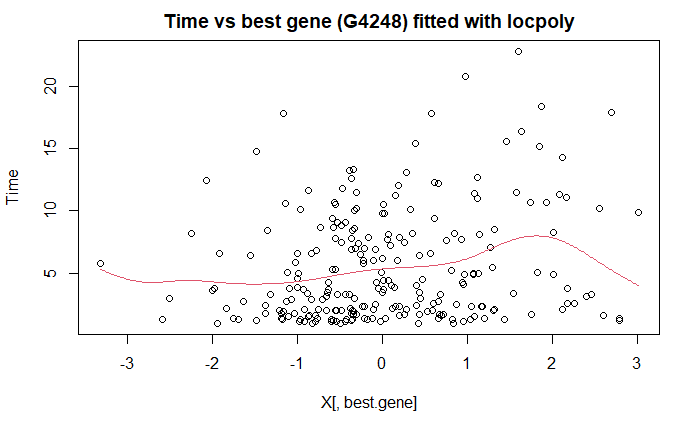

```r
fossil.loc <- locpoly(X[,best.gene], Time, bandwidth=h)
lines(fossil.loc, col=2)
```

```r
NA
NA
NA
```

# Task 6: Bootstrap confidence intervals (22 marks)

Continuing from Task 5 (with the same, single, predictor variable, and the same response `Time`), proceed with a more systematic analysis. Specifically, produce a nonparametric smoother featuring

- a principled way to select the smoothing parameter;
- bootstrapped confidence bands.

The smoothing method that you use in this Task may be the same or a different one as used in Task 5, but you are *not* allowed to make use of R function `gam`. If you use any built-in R functions to select the smoothing parameter or carry out the bootstrap, explain briefly what they do.

Produce a plot which displays the fitted smoother with the bootstrapped confidence bands. Add to this plot the regression line of a simple linear model with the only predictor variable being the chosen gene (beside the intercept).

Finally, report the values of $R^2$ of both the nonparametric and the parametric model. Conclude with a statement on the usefulness of the nonparametric model.

**Answer:**

```r
# ...

smooth.loc<- function(x,y,xgrid=x, h){
  N<-length(xgrid)
  smooth.est<-rep(0,N)

  for (j in 1:N){

    smooth.est[j]<- lm(y~I(x-xgrid[j]),
    weights=dnorm(x,xgrid[j],h) )$coef[1]
  }

  list(x= xgrid, fit=smooth.est)
}

h <- dpill(X[,best.gene], Time, truncate=FALSE)
Gene.loc <- smooth.loc(X[,best.gene], Time, h=h)


Gene.res <- Time - Gene.loc$fit
boot.fit <- matrix(0,200,dim(patient.data$x)[2])

for (j in 1:200){
  boot.res <- sample(Gene.res, size=dim(patient.data$x)[2])
  new.y <- Gene.loc$fit +boot.res

  ##### h selection
  h <- dpill(X[,best.gene], new.y, truncate=FALSE)

  boot.fit[j,] <- smooth.loc(X[,best.gene], new.y, h=h)$fit
}

lower<-upper<- rep(0,dim(patient.data$x)[2])
for (i in 1:dim(patient.data$x)[2]){
  lower[i]<-quantile(boot.fit[,i],0.025)
  upper[i]<-quantile(boot.fit[,i],0.975)
}

plot(X[,best.gene], Time, main = "Time vs best gene (G4248) using nonparametric smoother and confidence bands")
for (j in 1:200){ lines(X[,best.gene][order(X[,best.gene])], boot.fit[j,][order(X[,best.gene])], col="grey")}
```

```r
lines(X[,best.gene][order(X[,best.gene])], Gene.loc$fit[order(X[,best.gene])])
lines(X[,best.gene][order(X[,best.gene])], upper[order(X[,best.gene])], col=2, lwd=3)
```

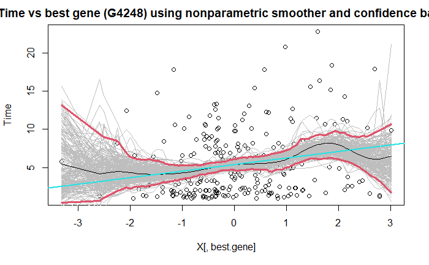

```r
lines(X[,best.gene][order(X[,best.gene])], lower[order(X[,best.gene])], col=2, lwd=3)

tt<-lm(Time ~ X[,best.gene], data = as.data.frame(X))


abline(tt, col=5, lwd=2)
```

```r
"R squared of parametric model"
```

```
[1] "R squared of parametric model"
```

```r
summary(tt)$r.squared
```

```
[1] 0.04814878
```

```r
""
```

```
[1] ""
```

```r
"R squared of non-parametric model"
```

```
[1] "R squared of non-parametric model"
```

```r
rr<- 1-(sum((Time-Gene.loc$fit)^2))/(sum((Time-mean(Time))^2))
rr
```

```
[1] 0.07944572
```

```r
"statement on the usefulness of the nonparametric model:
As you can see the non parametric model had a better r squared and therfore fitted the data better, non parametric models are also very useful as they usaully rquire less tuning in terms of hyperparamters. They are also a very general model which can be used in manyu applications.In this case they out performed the paramteric models making them very useful and easy to use! However only uing one of the genes to predict our response is not useful in either case and we get very poor r squared values."
```

```
[1] "statement on the usefulness of the nonparametric model:\nAs you can see the non parametric model had a better r squared and therfore fitted the data better, non parametric models are also very useful as they usaully rquire less tuning in terms of hyperparamters. They are also a very general mod…
```

```r
"I used the dpill to select my smoothing paramter, This simply finds the bandwidth h which minimises the integrated asymptotic mean squared error where h ~ n^-1/5"
```

```
[1] "I used the dpill to select my smoothing paramter, This simply finds the bandwidth h which minimises the integrated asymptotic mean squared error where h ~ n^-1/5"
```